# Title : Prediction of severity levels for vehicle accidents in France

1. Executive Summary
   - 1.1 Objective
   - 1.2 Problem
   - 1.3 Solution
   - 1.4 Value Proposition
   - 1.5 Findings and Conclusion
2. Introduction
3. Methods
   - 3.1 Fusion and join of different dataframes
   - 3.2 Data inspection
   - 3.3 EDA
   - 3.4 Data Preparation for modeling
   - 3.5 Multiclass and binary severity levels
   - 3.6 ML Models and Hyperparameter tuning
4. Results
5. Conclusion
6. References

## 1. Executive Summary

### 1.1 Objective

The objective of this Capstone Project is to predict the severity levels in the vehicle accidents in France. For this analysis, I took the data between 2019 and 2022.

### 1.2 Problem

Knowing that the initial project is to prevent more vehicles accidents per year, it will be useful to predict the kind of severity when an accident is produced. Based on that, the future actions could be taken in place to decrease the severities of accidents. This analysis could be useful as a criteria for assurance companies to estimate the assurances prices too.

### 1.3 Solution

The solution includes several steps:

1. Import of the data source: Base on the public source data.gouv.fr [1]
2. Preprocessing of the data: Conversion of some fields and deletion of not necessary fields
3. Analysis of the data: Pairplots, correlation analysis and filtering of values
4. Split of the data and scaling
5. Modelling: I used the following algorithms to compare and get the results: K-Nearest Neighbours (KNN), Linear Support Vector Machines (Linear SVM), Decision Trees, Random Forest, Light Gradient-Boosting Machine (LGBM) and eXtreme Gradient-Boosting (XGBoost)
6. Those results included the comparison for two ways: multiclass and binary output
7. For the hyperparameter tuning, the used of Halving Grid Search CV accelarated the search of parameter candidates to find the best accuracy.

### 1.4 Value Proposition

The results could be used to prevent future vehicle accidents and even used as a reference in the estimation of vehicles assurances.

## 2. Introduction

During the Capstone Project, I used the different knowledge studied in this course and apply it in a Study Case, I decided to analyze the different accidents in France between 2019 and 2022.

The objective of this project is being able to predict the severity level of the accidents produced in France in the mostly visited places in France.  
Due to the constraints of time and computing, I only opted to analyze some departments in France, including Ile-de-France.

## 3. Methods

### 3.1 Fusion and join of different dataframes

The different files contained key values that I joined them. After this, all those dataframes were fusioned in one dataframe and they were used to the following step.

### 3.2 Data inspection

There were different different ways to do the inspection and I had used the references found in [2] and [3]

One of the first steps was to delete not important fields or redundant fields.  
As a second step, it was the extraction of more fields based on the datetime of the accident.  
As a third step, there was the inspection of the departments with the biggest accidents amounts. The result is showed in the following figure:

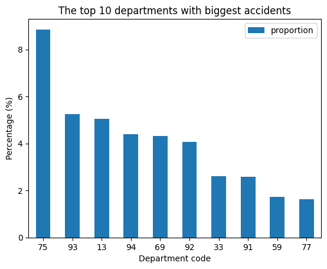

**Figure 1.** Top 10 departments with the biggest accident amounts

It shows the first step to take into account and consider the most significant data to analyse.

The next step is to analyse the histograma of the sex in the vehicle accidents and it allows to identify and delete the not coherent values:

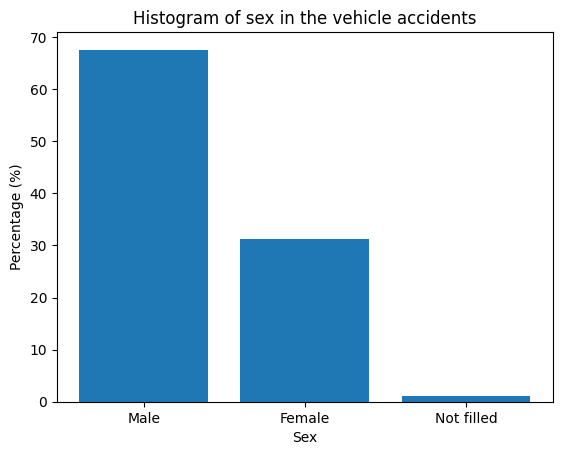

**Figure 2.** Histogram of the sex in the accidents

Due to time constraints, I will only analyse the departments with the biggest severity level in each range. The examples are in the Figures 3 and 4:

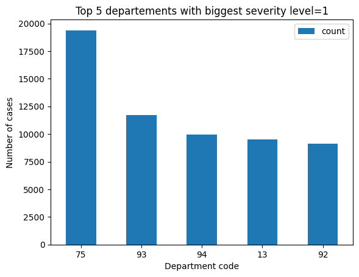

**Figure 3.** Top 5 departments with the biggest severity level = 1

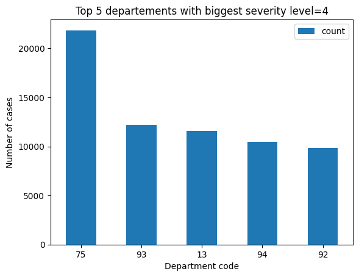

**Figure 4.** Top 5 departments with the biggest severity level = 4

Once I have filtered the most important departments, with the biggest severity level in each category, the result is showed in the Figure 5.

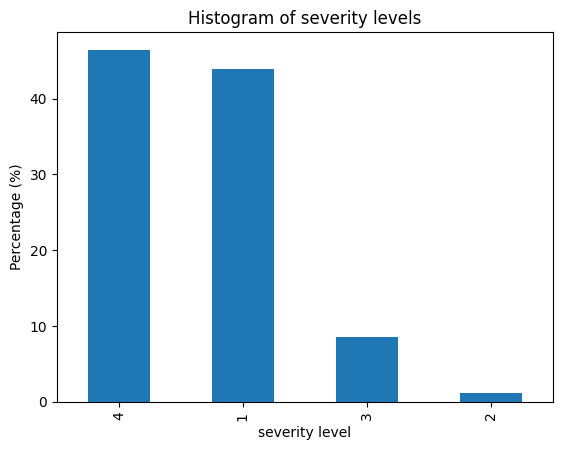

**Figure 5.** Histogram of severity levels

The next is to count the NA values and identify the fields that contain them (Figure 6). The actions taken for those fields are the following:

1. Delete the entire field for the biggest amount of NA values
2. Delete the rows which contains few NA values

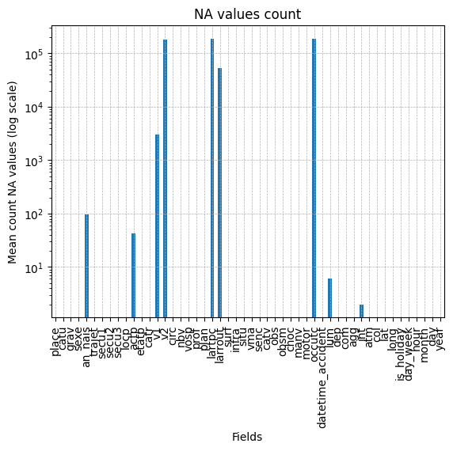

**Figure 6.** NA values count of the fields (log scale)

After this step, there were more inspection of the fields to identify and delete incoherent values. For example, nbv field contained incoherent values, for example the value "#ERREUR" and "-1", that it could be seen in the Figure 7.

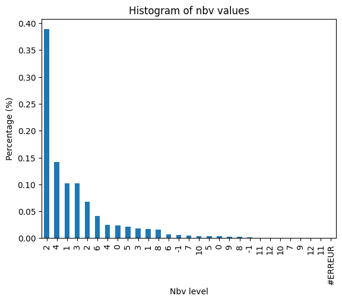

**Figure 7.** Histogram of the nbv field

### 3.3 EDA

The first step was to perform the correlation analysis based on the numeric values. The result is showed in the Figure 8:

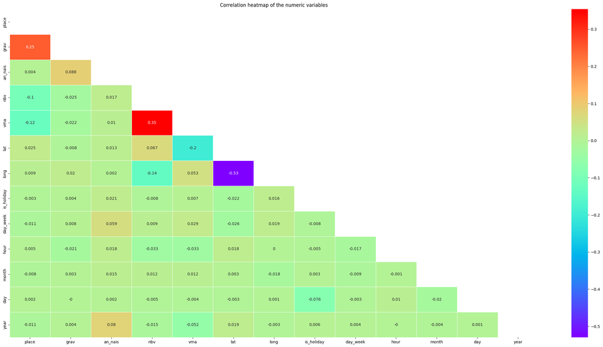

**Figure 8.** Heatmap of the correlation analysis

Based on this, I extracted the correlation only on the severity level values. That extraction is showed in the Figure 9:

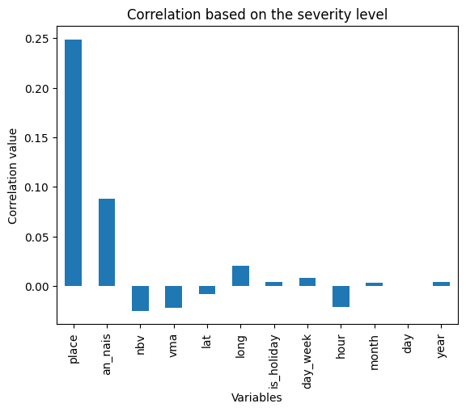

**Figure 9.** Correlation barchar based on the severity level

After this, I perform some relations between the severity level and some important fields. For example, severity level and the place shows more tendency to the front place and the accidents (showed in Figure 10).

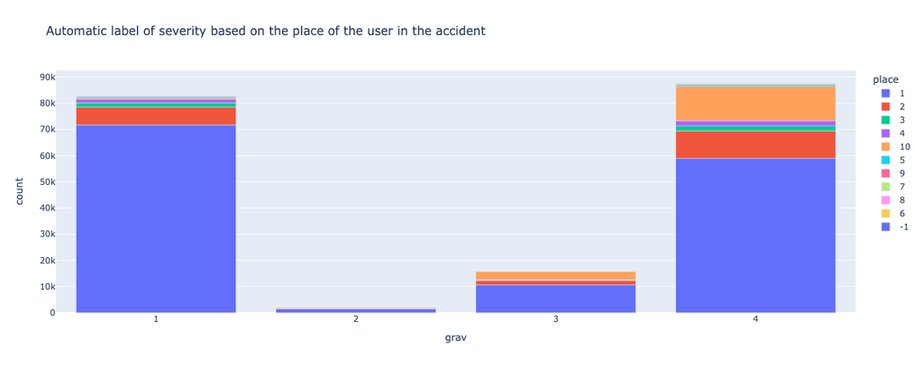

**Figure 10.** Relation between the severity level and the place

Other important relations are between severity level and motor type and between the severity level and the kind of vehicle which reveals use of hydrocarbons and light vehicles (showed in Figures 11 and 12).

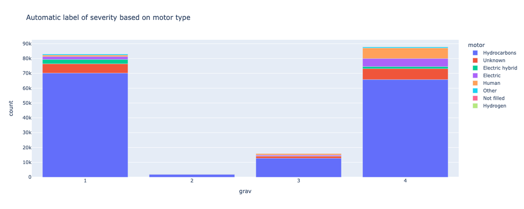

**Figure 11.** Relation between the severity level and the motor type

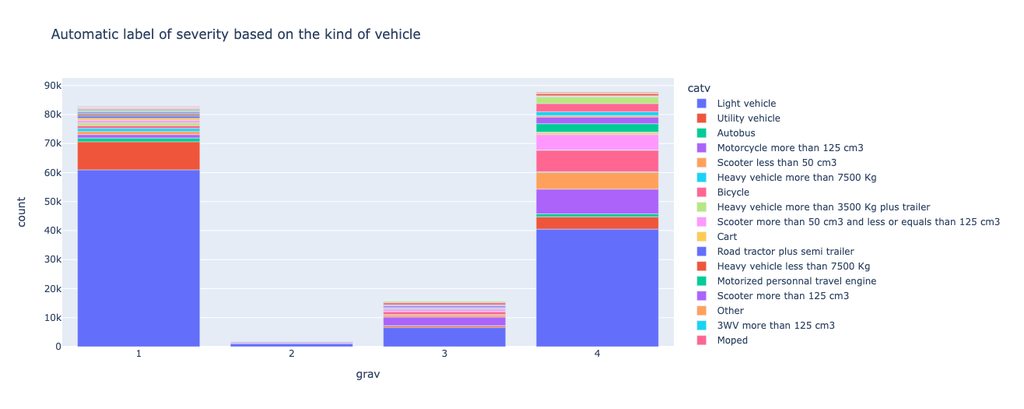

**Figure 12.** Relation between the severity level and the kind of vehicle

### 3.4 Data Preparation for modeling

For that step, two actions were performed:

1. Convert categorical variables: I used the get_dummies method and it will accelerate the process when we need to see the important features to take into account 2. Standardization of the data: That it is an important step because it will reduce the impact of outliers in our analysis and improve the performance of the ML models

### 3.5 Multiclass and binary severity levels

For the multiclass severity level, I kept the same values defined in the data and it will not impact the results.

For the binary sverity lvel, due to the complexity to predict the severity with more accuracy, I will modelize the data by grouping in two results: * 1 : Without any physical problem: Converted to 0 * 2, 3, 4 : With a physical problem (including minor accident until death): Converted to 1 That approach was based too in the following report based on work on Severity predictions for older years [[2](#reference-2)]  
The histogram of the binary severity level could be seen in the Figure 13.

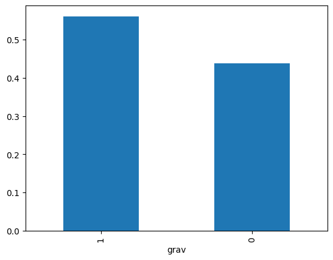

**Figure 13.** Histogram of severity levels in binary level

### 3.6 ML Models and Hyperparameter tuning

In this capstone, I used the following ML Classification models:

1. K-Nearest Neighbors: One of the first ML models used and it will used to mainly compare it with the other ML models
2. Support Vector Machines: For this case I used the Linear SVM Classification model (linear_svc in Pyhon) because it supports a large amount of data and the processing time is much faster than the library svm
3. Decision Tree
4. Random Forest
5. Light Gradient-Boosting Machine (LGBM): A model based on Gradient Boosting
6. eXtreme Gradient Boosting (XGBoost): A model based on Gradient Boosting

For the hyperparameter tuning, to accelerate the processing time, I used an experimental library which is known like Halving Grid Search CV. It implements a succesive halving of candidates based on multiple iterations. Each iteration increases the amount of ressources but reduces the number of candidates and some candidates are used in the last iteration [4]. A description of this is shown in the Figure 14, where the number of candidates is reduced on each iteration and the mean test score increases.

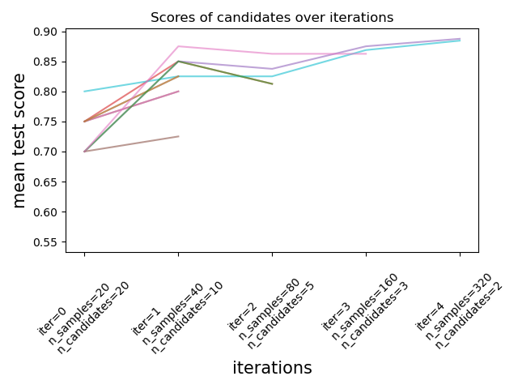

**Figure 14.** Halving Grid Search CV example. Source: Skit-learn.org

## 4. Results

After the hyperparameter tuning, the results obtained for the multiclass classification are in the Tables 1 and 2.

| Model | Accuracy | Precision per severity level 1 | Precision per severity level 2 | Precision per severity level 3 | Precision per severity level 4 | Recall per severity level 1 | Recall per severity level 2 | Recall per severity level 3 | Recall per severity level 4 | AUC per severity level 1 | AUC per severity level 2 | AUC per severity level 3 | AUC per severity level 4 |
| --- | --- | --- | --- | --- | --- | --- | --- | --- | --- | --- | --- | --- | --- |
| Baseline | 46.44% | 0 | 0 | 0 | 0.464484 | 0 | 0 | 0 | 1 | 0.5 | 0.5 | 0.5 | 0.5 |
| K-nearest neighbours | 99.98% | 0.999727 | 1.0 | 0.999765 | 0.999971 | 0.999985 | 1.0 | 0.999765 | 0.999728 | 1.0 | 1.0 | 1.0 | 1.0 |
| Linear SVC | 72.35% | 0.734892 | 0.9 | 0.521529 | 0.716439 | 0.858905 | 0.005053 | 0.075857 | 0.732351 | 0.889323 | 0.901627 | 0.839192 | 0.809478 |
| Decision Tree | 70.20% | 0.719636 | 0 | 0.517260 | 0.693389 | 0.814172 | 0 | 0.153672 | 0.714151 | 0.843088 | 0.798838 | 0.787286 | 0.780980 |
| Random Forest | 98.94% | 0.987346 | 1.0 | 0.998467 | 0.989510 | 0.994378 | 0.979787 | 0.968765 | 0.988745 | 0.999685 | 0.999999 | 0.999972 | 0.999600 |
| LGBM | 73.63% | 0.758275 | 0.782609 | 0.577945 | 0.723598 | 0.837675 | 0.050533 | 0.192422 | 0.757554 | 0.895603 | 0.926759 | 0.862253 | 0.835149 |
| XGBoost | 73.85% | 0.759270 | 0.623574 | 0.554003 | 0.731868 | 0.839372 | 0.092083 | 0.238923 | 0.750952 | 0.898174 | 0.931061 | 0.868609 | 0.837928 |

**Table 1.** Results found by severity level (multiclass) - Train data

LGBM Classifier and XGBoost had stable results in both steps. However, XGBoost Classifier had better results in AUC score and in recall score than LGBM Classifier.

| Model | Accuracy | Precision per severity level 1 | Precision per severity level 2 | Precision per severity level 3 | Precision per severity level 4 | Recall per severity level 1 | Recall per severity level 2 | Recall per severity level 3 | Recall per severity level 4 | AUC per severity level 1 | AUC per severity level 2 | AUC per severity level 3 | AUC per severity level 4 |
| --- | --- | --- | --- | --- | --- | --- | --- | --- | --- | --- | --- | --- | --- |
| Baseline | 46.44% | 0 | 0 | 0 | 0.464397 | 0 | 0 | 0 | 1 | 0.5 | 0.5 | 0.5 | 0.5 |
| K-nearest neighbours | 68.88% | 0.721815 | 0.211679 | 0.400724 | 0.686396 | 0.776155 | 0.065169 | 0.207955 | 0.710064 | 0.842584 | 0.649277 | 0.727170 | 0.770760 |
| Linear SVC | 72.37% | 0.735035 | 0 | 0.524336 | 0.716429 | 0.858892 | 0 | 0.074225 | 0.733089 | 0.888187 | 0.886714 | 0.835371 | 0.809183 |
| Decision Tree | 70.25% | 0.719972 | 0 | 0.519751 | 0.694217 | 0.814584 | 0 | 0.156593 | 0.714417 | 0.842687 | 0.791747 | 0.788429 | 0.782301 |
| Random Forest | 73.72% | 0.758263 | 0.445946 | 0.533458 | 0.735204 | 0.837132 | 0.074157 | 0.267147 | 0.745690 | 0.891591 | 0.822275 | 0.841790 | 0.829742 |
| LGBM | 73.66% | 0.757458 | 0.48 | 0.573308 | 0.725610 | 0.840284 | 0.026966 | 0.191043 | 0.756573 | 0.894939 | 0.903156 | 0.857806 | 0.834600 |
| XGBoost | 73.61% | 0.757536 | 0.435897 | 0.537572 | 0.730810 | 0.837799 | 0.076404 | 0.233010 | 0.748726 | 0.896431 | 0.915658 | 0.863734 | 0.835963 |

**Table 2.** Results found by severity level (multiclass) - Test data

After the hyperparameter tuning, the results obtained for the binary classification are in the Tables 3 and 4.

| Model | Accuracy | Precision | Recall | AUC |
| --- | --- | --- | --- | --- |
| Baseline | 56.12% | 0.561172 | 1.0 | 0.5 |
| K-nearest neighbours | 99.98% | 0.999917 | 0.999810 | 1.0 |
| Linear SVC | 67.67% | 0.719332 | 0.695209 | 0.741380 |
| Decision Tree | 78.34% | 0.844153 | 0.753025 | 0.851592 |
| Random Forest | 77.87% | 0.827823 | 0.764649 | 0.868567 |
| LGBM | 81.04% | 0.846295 | 0.809039 | 0.892285 |
| XGBoost | 82.83% | 0.857864 | 0.831850 | 0.911456 |

**Table 3.** Results found by severity level (binary) - Train data

As the multiclass classification, the results in test data step (Table 4) shows that K-Nearest Neighbors Classifier falls abruptly in all the scores and is has been surpassed by LGBM Classifier and XGBoost.

LGBM Classifier and XGBoost had stable results in both steps and better scores than the multiclass classification. However, XGBoost Classifier had better results in AUC score and in recall score than LGBM Classifier.  
Other important thing is that LGBM Classifier and XGboost Classifier had an accuracy more than 80% and XGBoost has an AUC score of 0.9, which it means the classifier has an outstanding discrimination.

| Model | Accuracy | Precision | Recall | AUC |
| --- | --- | --- | --- | --- |
| Baseline | 56.12% | 0.561165 | 1.0 | 0.5 |
| K-nearest neighbours | 77.92% | 0.816836 | 0.781912 | 0.853716 |
| Linear SVC | 67.64% | 0.718742 | 0.695644 | 0.741990 |
| Decision Tree | 78.51% | 0.844959 | 0.755605 | 0.855241 |
| Random Forest | 77.87% | 0.825918 | 0.767313 | 0.866727 |
| LGBM | 81.17% | 0.848367 | 0.809120 | 0.892852 |
| XGBoost | 82.02% | 0.850376 | 0.824620 | 0.902658 |

**Table 4.** Results found by severity level (binary) - Test data

A better way to see the capacity of each model, to predict different severity levels, are showed in the Confusion Matrix in the Figures 15, 16, 17 and 18.

In the Figure 15, we see that Random Forest Classifier and K-Nearest Neighbors Classifier are very good to predict severity levels, in multiclass classification, in the train data step.

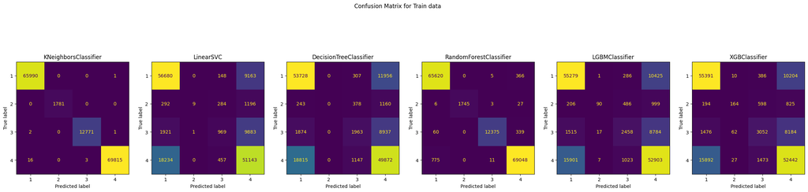

**Figure 15.** Confusion Matrix for severity level in multiclass - Train data

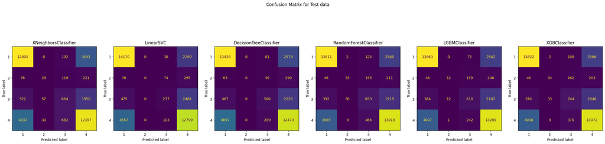

**Figure 16.** Confusion Matrix for severity level in multiclass - Test data

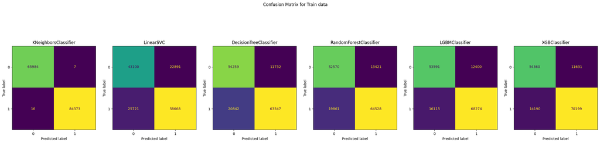

**Figure 17.** Confusion Matrix for severity level in binary - Train data

However, we see that behavior changes radically in the test step (Figure 18), where K-Nearest Neighbors Classifier falls down and it is not able to predict in the same way than in the train step. However, LGBM Classifier and XGBoost Classifier are much better in predicting severity levels and even XGBoost Classifier is the best to predict them.

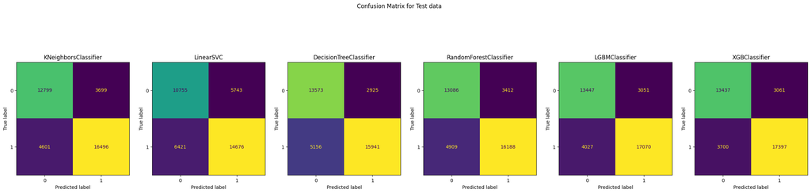

**Figure 18.** Confusion Matrix for severity level in binary - Test data

[output not shown]

A better way to see the AUC score is by the ROC Curve. We see the ROC Curves for XGBoost in the Figures 19, 20, 21 and 22.

In the muliclass classification (Figures 19 and 20), for train data step and test data step, XGBoost had good results with the curves being closer to the True Positive Rate side. That is a good indicator that the model is predicting better the severity levels. However, this prediction is not enough for all the severity levels.

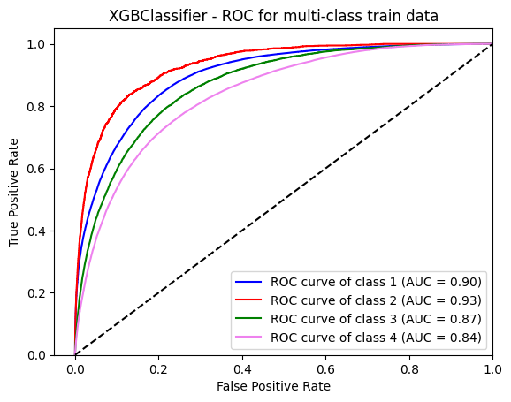

**Figure 19.** ROC for XGBoost Classifier - severity multiclass level - Train data

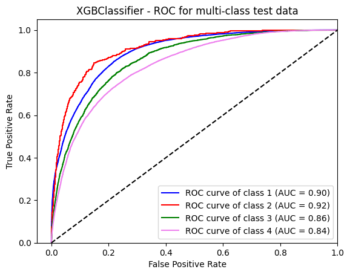

**Figure 20.** ROC for XGBoost Classifier - severity multiclass level - Test data

In binary classification (Figure 21 and 22), the ROC curve improved a lot and now it shows it much closer to the True Positive Rate side.

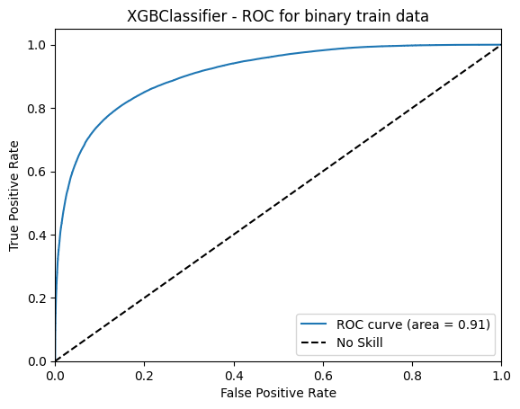

**Figure 21.** ROC for XGBoost Classifier - severity binary level - Train data

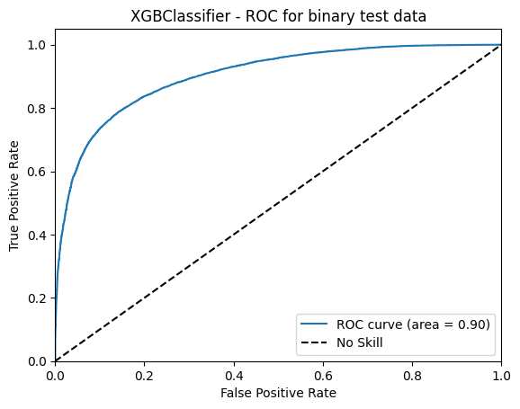

**Figure 22.** ROC for XGBoost Classifier - severity binary level - Test data

Other important thing to analyze is the Feature Importance diagram. For the case of multiclass classification (Figure 23), it reveals interesting things:

1. Firstly, in the accidents, people were using belt and helmet but they were using other security equipment which has not been identified.
2. The walker variable had relevance to identify the severity levels and the place of the accident is important too.
3. The manouver of turning left and opening door have important relevances in the accidents.
4. However, some people were not using security equipment during the accident which could imply a modification of the severity level.
5. The urban area and the Municipal road are variables to discriminate the severity level.
6. The presence of not obstacle in the vehicle accident is an important factor to take into account too.

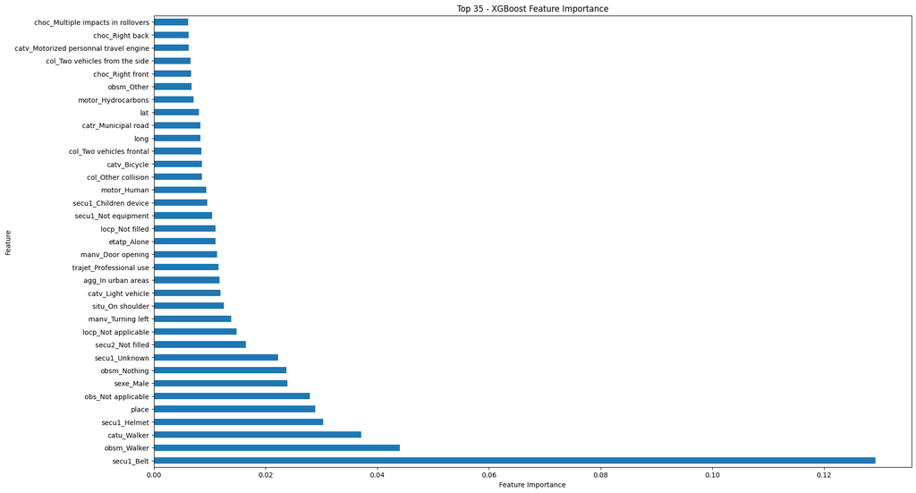

**Figure 23.** Top 35 Feature Importance Graphic - XGBoost Classifier - Severity multiclass level

For the case of binary classification (Figure 24), showed important modifications in comparison to the multiclass classification:

1. The use of gants is showed as a variable to discriminate the severity level.
2. The use of not security equipment took a lot of relevance to discriminate the severity level too.
3. The use of the utility vehicle has escalated as a very important variable too.

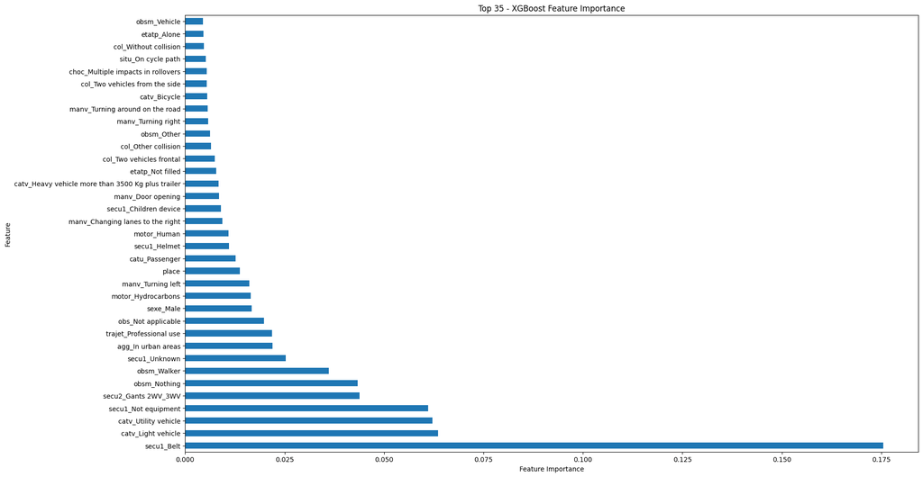

**Figure 24.** Top 35 Feature Importance Graphic - XGBoost Classifier - Severity binary level

In both cases there are variables that are surprisingly not considered so relevant:

1. Maximum authorized speed: Which it means security equipment had much more importance in comparison to the speed to decrease the severity level. It could sound counterintuitive but, during the vehicle accident, if the driver has respected the speed limit, the security equipment could help him to decrease his severity level.
2. Latitude and longitude: Similar to the maximum authorized speed, during the vehicle accident, if the drive has respected the rules, that variable will not take so much relevance.

Finally, It does not mean we do not take into account those variables, it means that the drivers were respecting mostly the security rules. If they did not respect them, I think the Feature Importance graphic could have changed radically.

## 6. References

1. Bases de données annuelles des accidents corporels de la circulation routière - Années de 2005 à 2022. Link: https://www.data.gouv.fr/fr/datasets/bases-de-donnees-annuelles-des-accidents-corporels-de-la-circulation-routiere-annees-de-2005-a-2022/
2. Étude de la sinistralité automobile par des méthodes de machine learning - Abdoul Malick BUARI, Thomas LE BRIGAND, Arstan UMAROV - 2018. Link: https://www.univ-brest.fr/euria/sites/euria.nouveau.univ-brest.fr/files/2022-06/explication_frequence_sinistralite_2017-2018.pdf
3. Identification et localisation sur le réseau routier national non concédé - Sétra - 2010. Link: https://dtrf.cerema.fr/pdf/pj/Dtrf/0005/Dtrf-0005792/DT5792.pdf?openerPage=resultats&qid=sdx_q0
4. Halving Grid Search CV. Link: https://scikit-learn.org/stable/modules/grid_search.html#successive-halving-user-guide
5. KNeighborsClassifier documentation. Link: https://scikit-learn.org/stable/modules/generated/sklearn.neighbors.KNeighborsClassifier.html
6. LinearSVC doumentation. Link: https://scikit-learn.org/stable/modules/generated/sklearn.svm.LinearSVC.html
7. DecisionTreeClassifier documentation. Link: https://scikit-learn.org/stable/modules/generated/sklearn.tree.DecisionTreeClassifier.html
8. RandomForestClassifier documentation. Link: https://scikit-learn.org/stable/modules/generated/sklearn.ensemble.RandomForestClassifier.html
9. lightgbm.LGBMClassifier documentation. Link: https://lightgbm.readthedocs.io/en/latest/pythonapi/lightgbm.LGBMClassifier.html
10. XGBoost Parameters. Link: https://xgboost.readthedocs.io/en/stable/parameter.html